# Part II - Prosper Loan Data - Investigation

## Investigation Overview

In this Part 2 investigation of the Prosper Loan Data set, I am going to show how home ownership and a borrower's income has a direct effect on how much an individual can borrow and at what rate they can borrow.

## Dataset Overview

This data set contains information about individuals who have received personal loans from Prosper between 2005 and 2014. This data set contains 95,703 loans with 15 variables on each loan, including loan amount, borrower rate (or interest rate), borrower information, debt-to-income ratio and many others.

```python
# import all packages and set plots to be embedded inline
import numpy as np
import pandas as pd
import matplotlib.pyplot as plt
import seaborn as sns

%matplotlib inline

# suppress warnings from final output
import warnings
warnings.simplefilter("ignore")
```

```python
# load in the dataset into a pandas dataframe
loan_df = pd.read_csv('Prosper_Loan_Clean.csv')


# Create my labels function for all graphs
def labels(title, x_label, y_label):
    plt.title(title)
    plt.xlabel(x_label)
    plt.ylabel(y_label)
```

## Box Plot of Income and Loan Amount with Home Ownership

This graph shows the relationship between income and loan amount along with the difference in home ownership.

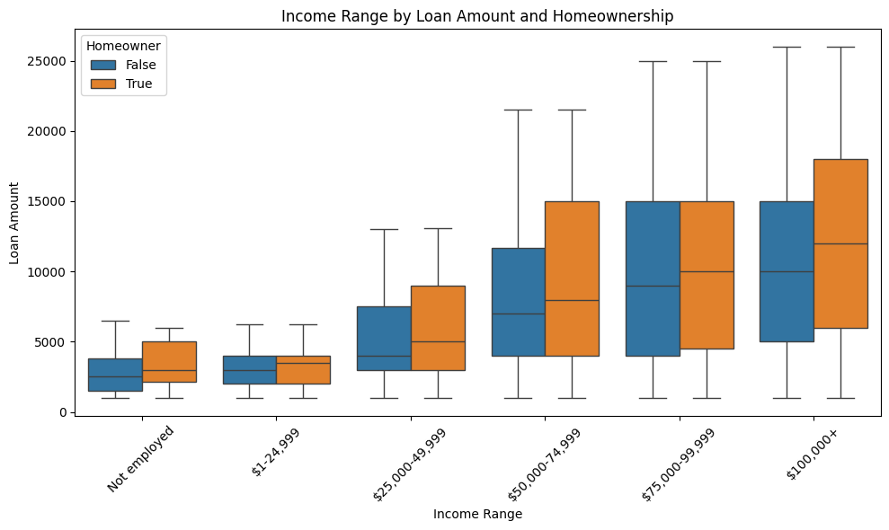

```python
# Box Plot of IncomeRange by LoanOriginalAmount and HomeOwnership

income_order = [
    'Not employed',
    '$1-24,999',
    '$25,000-49,999',
    '$50,000-74,999',
    '$75,000-99,999',
    '$100,000+'
    ]

plt.figure(figsize=(10, 6))
sns.boxplot(
    data=loan_df,
    x='IncomeRange',
    y='LoanOriginalAmount',
    hue='IsBorrowerHomeowner',
    order=income_order
    )

labels('Income Range by Loan Amount and Homeownership', 'Income Range', 'Loan Amount')
plt.xticks(rotation=45)
plt.legend(title='Homeowner')
plt.tight_layout()
plt.show()
```

It is to be expected that lenders will loan more money to borrowers who earn more money. This graph shows that as a borrower's income increases, so does the total loan amount. In addition to that, this chart also includes the added detail of borrowers that own a home or not. The orange boxes show the data of borrowers who own a home and took a loan out with Prosper. In every income range category, the median loan amount for borrowers who own a home compared to borrowers who don't, is higher.

## Violin Plot with Borrower Rate by Income and Homeownership

I'm now going to use a violin plot to again show how a borrower's income and homeowneship can affect their loan APR

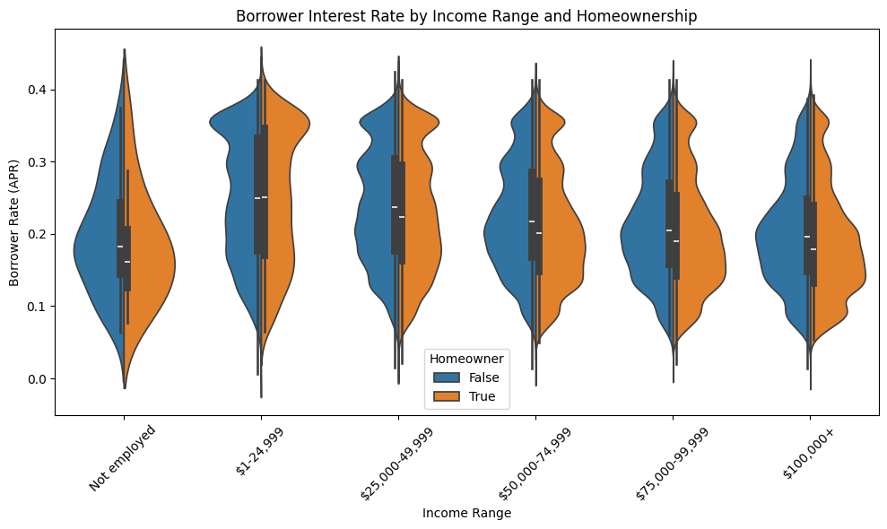

```python
plt.figure(figsize=(10, 6))
sns.violinplot(
    data=loan_df,
    x='IncomeRange',
    y='BorrowerAPR',
    hue='IsBorrowerHomeowner',
    split=True,
    order=income_order
)
labels('Borrower Interest Rate by Income Range and Homeownership', 'Income Range', 'Borrower Rate (APR)')
plt.xticks(rotation=45)
plt.legend(title='Homeowner')
plt.tight_layout()
plt.show()
```

Here again we see how the borrower's income and homeownership affect the loan's interest rate. In this chart, we see how the borrower's income is inversely correlated to the loans APR. This is true whether the borrower owns a home or not. For borrower's who own a home, the inverse correlation is more drastic.

## Scatterplot of DTI vs APR by Homeownership

For my final graph showing the affects of the borrower's financial health on loans, I'm using a scatterplot to compare the borrower's debt-to-income ratio against the loan's APR between borrower's who own a home and who don't.

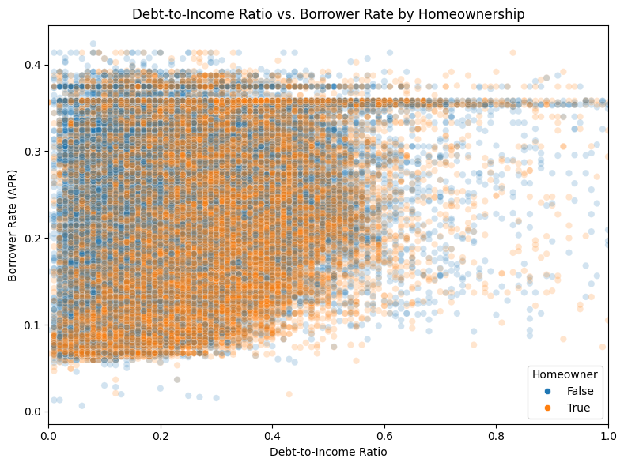

```python
plt.figure(figsize=(8, 6))
sns.scatterplot(
    data=loan_df,
    x='DebtToIncomeRatio',
    y='BorrowerAPR',
    hue='IsBorrowerHomeowner',
    alpha=0.2
)
labels('Debt-to-Income Ratio vs. Borrower Rate by Homeownership', 'Debt-to-Income Ratio', 'Borrower Rate (APR)')
plt.xlim(0,1)
legend = plt.legend(title='Homeowner')
for lh in legend.legend_handles:
    lh.set_alpha(1) # Set alpha to 1 for full opacity

plt.tight_layout()
plt.show()
```

The orange dots represent borrower's who own a home compared between their DTI and loan APR. What's interesting to note is that borrowers who DON'T own a home, the blue dots, are clustered primarily between APRs .13 to .35 and DTIs 0.03 to .2. That means that this lender is likely more likely give a loan to a borrower who doesn't own a home but has a low DTI. Conversely, borrower's who do own a home can afford to have a higher DTI to get a loan. This might be the case that lenders are potentially more trusting of a borrower who already have debt that they are currently paying on and meeting their monthly payments.

```python
!jupyter nbconvert --to html JMoore_Project_3_Part_2.ipynb
```

[output not shown]